# RSC_processing2022

Nicole Adams

2022-06-21

# Seq processesing for 2022 sequencing run of Red Swamp Crayfish

Samples were sequenced at MSU’s RTSF Genomics Core, project ID ADA12634 (RSC_novaSeq_2022). We submitted a single pool made up of 24 Illumina compatible libraries. The pool was QC’d and quantified using a combination of Qubit dsDNA HS, Agilent 4200 TapeStation HS DNA1000 and Invitrogen Collibri Library Quantification qPCR assays. The pool was loaded onto one (1) lane of a NovaSeq S4 flow cell and sequencing performed in a 2x150bp paired end read format using a NovaSeq 6000 v1.5 300 cycle reagent kit. Base calling was done by Illumina Real Time Analysis (RTA) v3.4.4 and output of RTA was demultiplexed and converted to FastQ format with Illumina Bcl2fastq v2.20.0. Sequencing report: 20220616_SeqProduction_Scribner.xlsx

## Download raw sequence data from RTSF

Bash commands for getting raw data from MSU RTSF to MSU HPCC. Following the RTSF [instructions](https://rtsf.natsci.msu.edu/genomics/data-retrieval/#HPCC)

```bash
# FTPS transfer from the RTSF FTP server to the HPCC only works if you are currently working from the rsync login node. Data for this run is in subdirectory 20220616_DNASeq_PE150

cd /mnt/home/adamsn23/RedSwampCrayfish/rawData2022

module load GCCcore/6.4.0 wget/1.19.4

#wget -r -np -nH --ask-password ftps://<username>@<hostname>/<directory_name>
wget -r -np -nH --ask-password ftps://scribnerk@titan.bch.msu.edu/20220616_DNASeq_PE150

# check files with md5
for FILE in *gz; do md5sum $FILE; done

# in excel I compared content of md5.txt with the result of md5 check and they were the same
```

```bash
# /Users/neasci/Documents/crayfish_lab/RSCseq2022

adamsn23@gateway.hpcc.msu.edu:"/mnt/home/adamsn23/RedSwampCrayfish/rawData2022/20220616_DNASeq_PE150/FastQC/*.html" .

# I renamed rawData2022 and the raw data directory
mv rawData2022/ seq2022/
mv 20220616_DNASeq_PE150/ rawData2022/
```

#### Load in R libraries

```r
library(tidyverse)
library(data.table)
library(viridisLite)
library(readxl)
library(googlesheets4) #access Google drive with RSC sample data see https://www.tidyverse.org/blog/2020/05/googlesheets4-0-2-0/
library(lubridate)
library(kableExtra)
library(ggrepel)
library(ggpubr)
```

### Look at sequence results taken from 20220616_SeqProduction_Scribner.xlsx

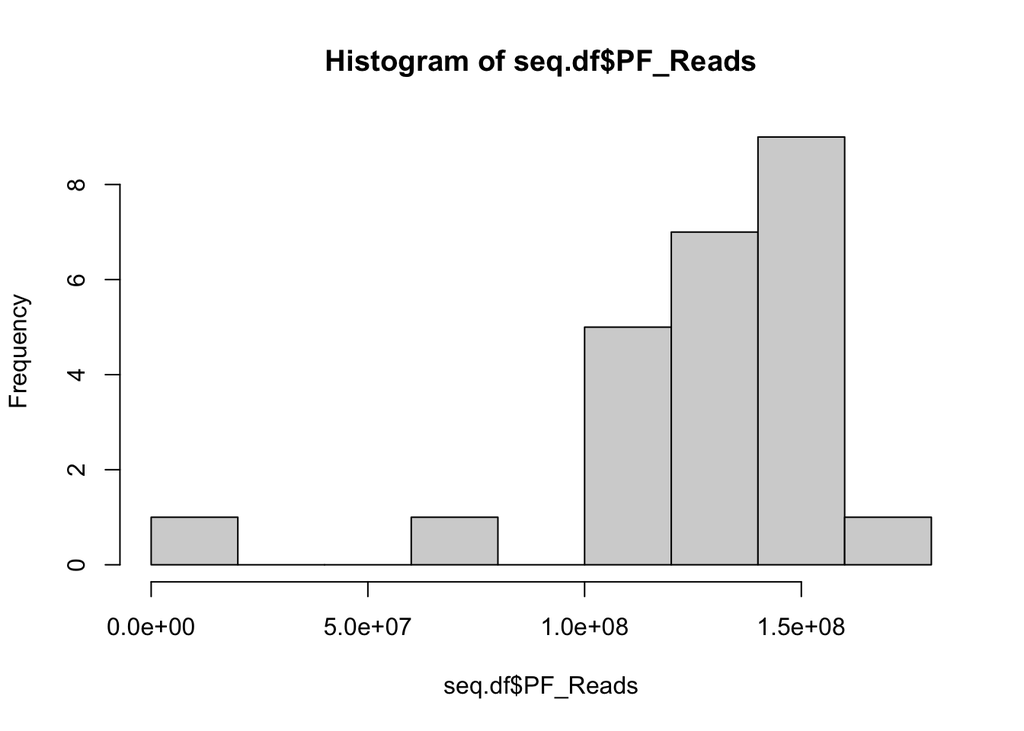

```r
seq.df <- read_excel("/Users/neasci/Documents/crayfish_lab/RSCseq2022/20220616_SeqProduction_Scribner.xlsx", sheet = "Sheet 1", skip = 14)

# Tidy data
seq.df <- seq.df %>% filter(!Lane == "Total")
seq.df <- seq.df %>% filter(!`Sample Name` == "PhiX+Undeter")

seq.df <- dplyr::rename(seq.df, Sample_ID =`Sample ID`, SampleName =`Sample Name`, PF_Reads=`PF Reads`, PF_Reads_perc=`% of PF Reads`, R1Q30_perc=`R1\r\n% ≥ Q30`, R2Q30_perc=`R2\r\n% ≥ Q30`, R1avgQ=`R1 Ave\r\nQ-Score`, R2avgQ=`R2 Ave\r\nQ-Score`, dataYield=`Yield (Gbp)`)

seq.df <- seq.df %>% separate(SampleName, into = c("no", "library"), sep = "_") %>% select(!no)

hist(seq.df$PF_Reads)
```

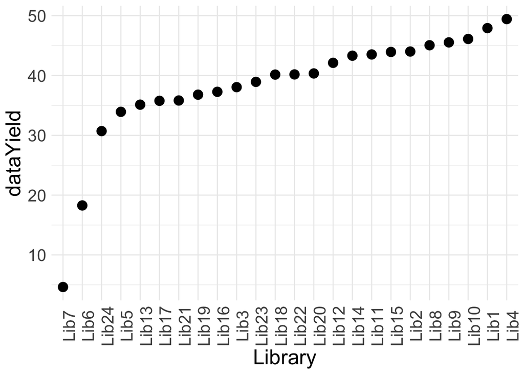

```r
ggplot(seq.df, aes(x=reorder(library, dataYield), y=dataYield)) +
  geom_point(size =4) +
  xlab("Library") +
  theme_minimal() +
  theme(axis.text.x = element_text(angle = 90), text = element_text(size = 20))
```

## Set up METADATA for analyses

```r
# ADULTS
# load in Adults Sample_database data and tidy
# Sheet 'Adults' from file 'Sample_database' from the Red Swamp Crayfish Google Drive
gs4_deauth()
samp <- read_sheet("https://docs.google.com/spreadsheets/d/1xEoqyWX1L-ZEvJLzepyNQK9n5s05p7cv-nKzHn4yFFM/edit?usp=sharing", sheet= "Adults", col_types = "ccicciciiicccc")

# tidy columns
# rename cols to remove spaces and special characters
samp <- dplyr::rename(samp, Site_Abbrev =`Site Abbrev.`, Sample_ID =`Sample ID`, Carap_mm =`Carap-mm`, ND_conc =`ND-conc`, Seq_library =`Seq. library`, Tissue_location=`Tissue location`, Extracted_DNA_location=`Extracted DNA location`)

samp <- as.data.frame(samp)

# ** Is River Oaks different from River Oaks (2 ponds)? NO
# ** Is Holiday 1 the same as Holiday Inn 1 and same with 2? YES
# ** What is Holiday II? Holiday Inn 2? SAME
# ** What is Preserve of Meadowbrook? DIFFERENT
# Fix site names (capitalization, spelling, spaces, etc.)
samp$Site <- gsub("(M", "M", samp$Site, fixed = TRUE)
samp$Site <- gsub("Q)", "Q", samp$Site, fixed = TRUE)
samp$Site <- gsub("River Oaks (2 ponds)", "River Oaks", samp$Site, fixed = TRUE)
samp$Site <- gsub("Holiday 1", "Holiday Inn 1", samp$Site)
samp$Site <- gsub("Holiday 2", "Holiday Inn 2", samp$Site)
samp$Site <- gsub("Holiday II", "Holiday Inn 2", samp$Site)

# add lifestage
samp$stage <- "adult"

# pull out samples seq'd in 2019 and 2020
samp2020 <- samp %>% filter(Year %in% c(2019,  2020))
#write.table(samp2020, file=paste0("~/Documents/crayfish_lab/RSCseq2022/adults2020_meta.txt"), sep="\t", row.names=FALSE, col.names=TRUE, quote=FALSE)

# pull out samples seq'd in 2022
plates2keep <- c("Plate 07-08-21", "Plate 08-31-21", "Plate 9-23-21", "Plate 10-14-21", "Plate 10-20-21", "Plate 10-28-21", "Plate 11-30-21")
samp2022 <- samp %>% filter(Extracted_DNA_location %in% plates2keep)

# JUVENILES
gs4_deauth()
juvs <- read_sheet("https://docs.google.com/spreadsheets/d/1xEoqyWX1L-ZEvJLzepyNQK9n5s05p7cv-nKzHn4yFFM/edit?usp=sharing", sheet= "Juveniles", col_types = "ccicciciiicccc")

# tidy columns
# rename cols to remove spaces and special characters
juvs <- dplyr::rename(juvs, Site_Abbrev =`Site Abbrev.`, Sample_ID =`Sample ID`, Carap_mm =`Carap-mm`, ND_conc =`ND-conc`, Seq_library =`Seq. Lib`, Tissue_location=`Tissue location`, Extracted_DNA_location=`Extracted DNA location`)

juvs <- as.data.frame(juvs)

# fix dates - for date ranges, take first date
juvs$Date2 <- str_split(juvs$Date, "-", simplify = T)[,1]
juvs$Date2 <- mdy(juvs$Date2, truncated = 2)
juvs$Date2 <- format(as.Date(juvs$Date2), "%m-%d")

# fix site names
juvs$Site <- gsub("Meadow Brook 1", "Meadowbrook Pond 1", juvs$Site)
juvs$Site <- gsub("Meadowbrook1", "Meadowbrook Pond 1", juvs$Site)
juvs$Site <- gsub("Meadowbrook 1", "Meadowbrook Pond 1", juvs$Site)
juvs$Site <- gsub("Foxcreek12", "Fox Creek 12", juvs$Site)
juvs$Site <- gsub("Foxcreek 12", "Fox Creek 12", juvs$Site)
juvs$Site <- gsub("Foxcreek 17b", "Fox Creek 17b", juvs$Site)

# add lifestage
juvs$stage <- "juvenile"

# pull out samples seq'd in 2019 and 2020
juvs2020 <- juvs %>% filter(Year %in% c(2019,  2020))
#write.table(juv.df2, file=paste0("~/Documents/crayfish_lab/RSCseq2022/juv2022_meta.txt"), sep="\t", row.names=FALSE, col.names=TRUE, quote=FALSE)

# pull out samples seq'd in 2022
plates2keep2 <- c("Plate 11-15-21", "Plate 11-18-21", "Plate 11-29-21", "Plate 12-2-21", "Plate 12-6-21 (2)", "Plate 12-9-21", "Plate 12-13-21 (2)")
juvs2022 <- juvs %>% filter(Extracted_DNA_location %in% plates2keep2)


# BERRIED FEMALES
gs4_deauth()
# load in moms
bf <- read_sheet("https://docs.google.com/spreadsheets/d/1xEoqyWX1L-ZEvJLzepyNQK9n5s05p7cv-nKzHn4yFFM/edit?usp=sharing", sheet= "Juvenile carriers_moms", skip = 1 , col_types = "cciicciiiicccccc")

# tidy columns
# rename cols to remove spaces and special characters
bf <- dplyr::rename(bf, Site_Abbrev =`Site Abbrev.`, Sample_ID =`Sample name`, Carap_mm =`Carap-mm`, Storage_location=`Storage location`, ND_conc =`ND-conc`, Seq_library =`Seq. Lib`, Tissue_location=`Tissue location`, Extracted_DNA_location=`Extracted DNA location`)

bf <- as.data.frame(bf)
bf <- bf %>% dplyr::select(-c(`...15`, `...16`)) %>% drop_na(Site)

# fix dates - for date ranges, take first date
bf$Date2 <- str_split(bf$Date, "-", simplify = T)[,1]
bf$Date2 <- mdy(bf$Date2, truncated = 2)
bf$Date2 <- format(as.Date(bf$Date2), "%m-%d")

bf$ExtractedDate <- str_split(bf$Extracted_DNA_location, " ", simplify = T)[,2]

# fix site names and years
bf$Site <- gsub("Meadowbrook 1", "Meadowbrook Pond 1", bf$Site)
bf$Site <- gsub("Meadowbrook 2", "Meadowbrook Pond 2", bf$Site)
bf$Site <- gsub("Foxcreek 16", "Fox Creek 16", bf$Site)
bf$Extracted_DNA_location <- gsub("Plate 11-3-2021", "Plate 11-3-21", bf$Extracted_DNA_location)
bf$Extracted_DNA_location <- gsub("Plate 11-10-2021", "Plate 11-10-21", bf$Extracted_DNA_location)
bf$Extracted_DNA_location <- gsub("Plate 11-16-2021", "Plate 11-16-21", bf$Extracted_DNA_location)

# add lifestage
bf$stage <- "berriedFemale"

# pull out samples seq'd in 2019 and 2020
bf2020 <- bf %>% filter(Year %in% c(2019,  2020))
#write.table(bf2020, file=paste0("~/Documents/crayfish_lab/RSCseq2022/bf2020_meta.txt"), sep="\t", row.names=FALSE, col.names=TRUE, quote=FALSE)

# pull out samples seq'd in 2022
plates2keep3 <- c("Plate 11-1-21", "Plate 11-4-21 (1)", "Plate 11-4-21 (2)", "Plate 11-8-21", "Plate 12-6-2021(1)", "Plate 12-8-21", "Plate 12-10-21")
bf2022 <- bf %>% filter(Extracted_DNA_location %in% plates2keep3)


# OFFSPRING OF BERRIED FEMALES
gs4_deauth()
# load in offspring of berried females
off <- read_sheet("https://docs.google.com/spreadsheets/d/1xEoqyWX1L-ZEvJLzepyNQK9n5s05p7cv-nKzHn4yFFM/edit?usp=sharing", sheet= "Juvenile carriers_offspring", skip = 1 , col_types = "cciicciiiccc")

# tidy columns
# rename cols to remove spaces and special characters
off <- dplyr::rename(off, Site_Abbrev =`Site Abbrev.`, Sample_ID =`Sample name`, ND_conc =`ND-conc`, Seq_library =`Seq. Lib`, Tissue_location=`Tissue location`, Extracted_DNA_location=`Extracted DNA location`)
```

```r
off <- as.data.frame(off)
off <- off %>% drop_na(Site)

# fix dates - for date ranges, take first date
off$Date2 <- str_split(off$Date, "-", simplify = T)[,1]
off$Date2 <- mdy(off$Date2, truncated = 2)
off$Date2 <- format(as.Date(off$Date2), "%m-%d")

off$ExtractedDate <- str_split(off$Extracted_DNA_location, " ", simplify = T)[,2]

# fix site names and dates
off$Site <- gsub("Meadowbrook 1", "Meadowbrook Pond 1", off$Site)
off$Site <- gsub("Foxcreek 16", "Fox Creek 16", off$Site)
off$Site <- gsub("Foxcreek 17b", "Fox Creek 17b", off$Site)
off$Extracted_DNA_location <- gsub("Plate 11-3-2021", "Plate 11-3-21", off$Extracted_DNA_location)
off$Extracted_DNA_location <- gsub("Plate 11-10-2021", "Plate 11-10-21", off$Extracted_DNA_location)
off$Extracted_DNA_location <- gsub("Plate 11-16-2021", "Plate 11-16-21", off$Extracted_DNA_location)
#off$Extracted_DNA_location <- gsub("Plate 12-6-2021(1)", "Plate 12-6-21(1)", off$Extracted_DNA_location)
off$Extracted_DNA_location <- gsub("Plate 12-8-2021", "Plate 12-8-21", off$Extracted_DNA_location)
off$Extracted_DNA_location <- gsub("Plate 12-10-2021", "Plate 12-10-21", off$Extracted_DNA_location)
#off$Extracted_DNA_location <- gsub("Plate 12-13-2021 (1)", "Plate 12-13-21 (1)", off$Extracted_DNA_location)
#off$Extracted_DNA_location <- gsub("Plate 12-13-2021 (2)", "Plate 12-13-21 (2)", off$Extracted_DNA_location)
off$Extracted_DNA_location <- gsub("Plate 12-16-2021", "Plate 12-16-21", off$Extracted_DNA_location)

# add lifestage
off$stage <- "offspring"

# pull out samples seq'd in 2019 and 2020
off2020 <- off %>% filter(Year %in% c(2019,  2020))
#write.table(off2020, file=paste0("~/Documents/crayfish_lab/RSCseq2022/off2020_meta.txt"), sep="\t", row.names=FALSE, col.names=TRUE, quote=FALSE)

# pull out samples seq'd in 2022
plates2keep4 <- c("Plate 11-1-21", "Plate 11-4-21 (1)", "Plate 11-4-21 (2)", "Plate 11-8-21", "Plate 12-6-2021(1)", "Plate 12-8-21", "Plate 12-10-21", "Plate 12-13-2021 (1)", "Plate 12-13-2021 (2)", "Plate 12-16-21")
off2022 <- off %>% filter(Extracted_DNA_location %in% plates2keep4)

# LIB24_COMBO plate details
combo <- read_tsv("~/Documents/crayfish_lab/libraryPreps/Lib24_combo.txt", col_names = T)
combo <- dplyr::rename(combo, Site_Abbrev =`Site Abbrev.`, Sample_ID =`Sample name`, Carap_mm =`Carap-mm`, Storage_location=`Storage location`, ND_conc =`ND-conc`, Seq_library =`Seq. Lib`, Tissue_location=`Tissue location`)
combo$Date2 <- str_split(combo$Date, "-", simplify = T)[,1]
combo$Date2 <- mdy(combo$Date2, truncated = 2)
combo$Date2 <- format(as.Date(combo$Date2), "%m-%d")

#plates2keep5 <- c("Plate 11-3-2021", "Plate 11-3-21", "Plate 11-10-2021", "Plate 11-10-21", "Plate 11-16-2021", "Plate 11-16-21")

combo$SequenceID <- gsub("FC17B", "FC17b", combo$SequenceID)
combo$Sample_ID <- gsub("FC17B", "FC17b", combo$Sample_ID)
combo$Seq_library <- as.integer(combo$Seq_library)
combo <- combo %>% filter(!SequenceID == "empty")



# COMBINE ALL METADATA for 2022
meta.dfA <- full_join(samp2022, juvs2022)
meta.dfB <- full_join(meta.dfA, bf2022)
meta.dfC <- full_join(meta.dfB, off2022)
meta.df <- full_join(meta.dfC, combo)


# Add library names
meta.df$library <- ifelse(meta.df$Extracted_DNA_location == "Plate 07-08-21", "Lib1", "foo")
meta.df$library <- ifelse(meta.df$Extracted_DNA_location == "Plate 08-31-21", "Lib2", meta.df$library)
meta.df$library <- ifelse(meta.df$Extracted_DNA_location == "Plate 9-23-21", "Lib3", meta.df$library)
meta.df$library <- ifelse(meta.df$Extracted_DNA_location == "Plate 10-14-21", "Lib4", meta.df$library)
meta.df$library <- ifelse(meta.df$Extracted_DNA_location == "Plate 10-20-21", "Lib5", meta.df$library)
meta.df$library <- ifelse(meta.df$Extracted_DNA_location == "Plate 10-28-21", "Lib6", meta.df$library)
meta.df$library <- ifelse(meta.df$Extracted_DNA_location == "Plate 11-30-21", "Lib7", meta.df$library)
meta.df$library <- ifelse(meta.df$Extracted_DNA_location == "Plate 11-15-21", "Lib8", meta.df$library)
meta.df$library <- ifelse(meta.df$Extracted_DNA_location == "Plate 11-18-21", "Lib9", meta.df$library)
meta.df$library <- ifelse(meta.df$Extracted_DNA_location == "Plate 11-29-21", "Lib10", meta.df$library)
meta.df$library <- ifelse(meta.df$Extracted_DNA_location == "Plate 12-2-21", "Lib11", meta.df$library)
meta.df$library <- ifelse(meta.df$Extracted_DNA_location == "Plate 12-6-21 (2)", "Lib12", meta.df$library)

meta.df$library <- ifelse(meta.df$Extracted_DNA_location == "Plate 12-9-21", "Lib13", meta.df$library)
meta.df$library <- ifelse(meta.df$Extracted_DNA_location == "Plate 12-13-21 (2)"| meta.df$Extracted_DNA_location == "Plate 12-13-2021 (2)", "Lib14", meta.df$library)
meta.df$library <- ifelse(meta.df$Extracted_DNA_location == "Plate 11-1-21", "Lib15", meta.df$library)
meta.df$library <- ifelse(meta.df$Extracted_DNA_location == "Plate 11-4-21 (1)", "Lib16", meta.df$library)
meta.df$library <- ifelse(meta.df$Extracted_DNA_location == "Plate 11-4-21 (2)", "Lib17", meta.df$library)
meta.df$library <- ifelse(meta.df$Extracted_DNA_location == "Plate 11-8-21", "Lib18", meta.df$library)
meta.df$library <- ifelse(meta.df$Extracted_DNA_location == "Plate 12-6-2021(1)", "Lib19", meta.df$library)
meta.df$library <- ifelse(meta.df$Extracted_DNA_location == "Plate 12-8-21", "Lib20", meta.df$library)
meta.df$library <- ifelse(meta.df$Extracted_DNA_location == "Plate 12-10-21", "Lib21", meta.df$library)
meta.df$library <- ifelse(meta.df$Extracted_DNA_location == "Plate 12-13-2021 (1)", "Lib22", meta.df$library)
meta.df$library <- ifelse(meta.df$Extracted_DNA_location == "Plate 12-16-21", "Lib23", meta.df$library)
meta.df$library <- ifelse(meta.df$SequenceID %in% combo$SequenceID, "Lib24", meta.df$library)

# Add year tags for sequence ID
libs2add22 <- c("Lib1", "Lib2", "Lib3", "Lib4", "Lib5", "Lib6", "Lib8", "Lib9", "Lib10", "Lib11", "Lib12",  "Lib13", "Lib14", "Lib15",  "Lib16", "Lib17", "Lib18", "Lib23")
meta.df$SequenceID <- ifelse(meta.df$library %in% libs2add22, paste0(meta.df$Sample_ID, "-22"), meta.df$SequenceID)
```

```r
meta.df$SequenceID <- ifelse(meta.df$library == "Lib7", meta.df$Sample_ID, meta.df$SequenceID) #some reason lib7 already has '-212' tacked onto the Sample_ID
meta.df$SequenceID <- ifelse(meta.df$library == "Lib19", paste0(meta.df$Sample_ID, "-20"), meta.df$SequenceID)
meta.df$SequenceID <- ifelse(meta.df$library == "Lib19"&meta.df$Sample_ID %in% c("FC17b-M2-212", "FC17b-M3-212", "FC17b-M4-212", "SHD-M2-212"), meta.df$Sample_ID, meta.df$SequenceID)

meta.df$SequenceID <- ifelse(meta.df$library == "Lib20", paste0(meta.df$Sample_ID, "-20"), meta.df$SequenceID)
meta.df$SequenceID <- ifelse(meta.df$library == "Lib21", paste0(meta.df$Sample_ID, "-20"), meta.df$SequenceID)

meta.df$SequenceID <- ifelse(meta.df$library == "Lib22"&meta.df$Year == "2020", paste0(meta.df$Sample_ID, "-20"), meta.df$SequenceID)
meta.df$SequenceID <- ifelse(meta.df$library == "Lib22"&meta.df$Year == "2021", paste0(meta.df$Sample_ID, "-22"), meta.df$SequenceID)

# Lib24 already has tag on sequenceID

# Fix name discrepancies
meta.df$Sample_ID <- gsub("FC17B", "FC17b", meta.df$Sample_ID)
meta.df$SequenceID <- gsub("FC17B", "FC17b", meta.df$SequenceID)
meta.df$Site_Abbrev <- gsub("FC17B", "FC17b", meta.df$Site_Abbrev)
meta.df$Site_Abbrev <- gsub("FC9B", "FC9b", meta.df$Site_Abbrev)
meta.df$Sample_ID <- gsub("FC9B", "FC9b", meta.df$Sample_ID)
meta.df$SequenceID <- gsub("FC9B", "FC9b", meta.df$SequenceID)

### make sample lists
adult.df <- meta.df %>% filter(stage == "adult")  %>% select(SequenceID)
#write.table(adult.df, file=paste0("~/Documents/crayfish_lab/RSCseq2022/adult2022_list.txt"), sep="\t", row.names=FALSE, col.names=FALSE, quote=FALSE)
adult.df2 <- meta.df %>% filter(stage == "adult")
#write.table(adult.df2, file=paste0("~/Documents/crayfish_lab/RSCseq2022/adult2022_meta.txt"), sep="\t", row.names=FALSE, col.names=T, quote=FALSE)

juv.df <- meta.df %>% filter(stage == "juvenile") %>% select(SequenceID)
#write.table(juv.df, file=paste0("~/Documents/crayfish_lab/RSCseq2022/juv2022_list.txt"), sep="\t", row.names=FALSE, col.names=FALSE, quote=FALSE)
juv.df2 <- meta.df %>% filter(stage == "juvenile")
#write.table(juv.df2, file=paste0("~/Documents/crayfish_lab/RSCseq2022/juv2022_meta.txt"), sep="\t", row.names=FALSE, col.names=TRUE, quote=FALSE)

bf.df <- meta.df %>% filter(stage == "berriedFemale") %>% select(SequenceID)
#write.table(bf.df, file=paste0("~/Documents/crayfish_lab/RSCseq2022/berriedFemales2022_list.txt"), sep="\t", row.names=FALSE, col.names=FALSE, quote=FALSE)
bf.df2 <- meta.df %>% filter(stage == "berriedFemale")
#write.table(bf.df2, file=paste0("~/Documents/crayfish_lab/RSCseq2022/berriedFemales2022_meta.txt"), sep="\t", row.names=FALSE, col.names=TRUE, quote=FALSE)

off.df <- meta.df[grepl(glob2rx('*-M*-J*'), meta.df$SequenceID),]
off.df2 <- off.df %>% select(SequenceID)
#write.table(off.df2, file=paste0("~/Documents/crayfish_lab/RSCseq2022/offspring2022_list.txt"), sep="\t", row.names=FALSE, col.names=FALSE, quote=FALSE)
#write.table(off.df, file=paste0("~/Documents/crayfish_lab/RSCseq2022/offspring2022_meta.txt"), sep="\t", row.names=FALSE, col.names=TRUE, quote=FALSE)

adultJuvBF <- meta.df %>% filter( stage %in% c("adult", "juvenile", "berriedFemale")) %>% select(SequenceID)
#write.table(adultJuvBF, file=paste0("~/Documents/crayfish_lab/RSCseq2022/adultJuvBF2022_list.txt"), sep="\t", row.names=FALSE, col.names=FALSE, quote=FALSE)

# save all seq2022 metadata to one file
#write.table(meta.df, file="~/Documents/crayfish_lab/RSCseq2022/seq2022_metadata.txt", sep="\t", row.names=FALSE, col.names=TRUE, quote=FALSE)
```

## Pre-processing

### Make directories needed for flipReads

```bash
# Create directories needed for 2_flipReads_NEA.sh
mkdir /mnt/home/adamsn23/RedSwampCrayfish/seq2022/scripts
mkdir /mnt/home/adamsn23/RedSwampCrayfish/seq2022/QSTAT
mkdir /mnt/home/adamsn23/RedSwampCrayfish/seq2022/SHELL
mkdir /mnt/home/adamsn23/RedSwampCrayfish/seq2022/SHELL/dependencies

#mkdir /mnt/gs18/scratch/users/adamsn23/RSC/
mkdir /mnt/gs21/scratch/adamsn23/RSC/seq2022 # new HPCC scratch space, used to be /mnt/gs21/scratch/gs18
```

### Make files with list of barcodes for each library

```r
pg.files <- list.files(path="~/Documents/crayfish_lab/libraryPreps/picoGreen", pattern='*.xlsx', full.names = TRUE)
barcodes <- read_excel("~/Documents/crayfish_lab/libraryPreps/bestRADindexes_6-28-2022.xlsx", sheet="vertical")

pgList <- list()
for (FILE in pg.files){
  pg <- read_excel(FILE, sheet = "Data Analysis- new 021022")
  LIB1 <- unlist(strsplit(FILE, "[/|,.,_]+"))[c(9)]
  LIB2 <- unlist(strsplit(LIB1, "[' ']+"))[c(7)]
  dfName <- paste( LIB2, "df", sep = '.' )
  pg.df <- pg %>% select(`Well Position`, `Sample Name...3`, `Corrected [DNA] ng/ul   (by multiplying column G by dilution factor from column B)`) %>% rename(plateWell=`Well Position`, sampleID=`Sample Name...3`, DNAconc_pg=`Corrected [DNA] ng/ul   (by multiplying column G by dilution factor from column B)`) %>% mutate(library=LIB2) %>% filter(!row_number() %in% c(97, 98, 99))
  pg.df <- full_join(pg.df, barcodes)
  pgList[[dfName]] <- pg.df
  barcode4file <- pg.df %>% select(RADbarcode, sampleID)
  #write.table(barcode4file, file=paste0("~/Documents/crayfish_lab/libraryPreps/", LIB2, "_barcodes.txt"), sep="\t", row.names=FALSE, col.names=FALSE, quote=FALSE)
  #write.table(pg.df, file=paste0("~/Documents/crayfish_lab/RSCseq2022/", LIB2, "_meta.txt"), sep="\t", row.names=FALSE, quote=FALSE)
}

pg.bigA <- do.call("rbind", pgList) # 2304 rows
empties <- pg.bigA %>% filter(duplicated(.[["sampleID"]])) # 20 "empty" rows from Libs 1,5,7,11,17,24
pg.big <- pg.bigA %>% filter(!sampleID == "empty") # 2283 rows
```

#### Copy barcode files to HPCC

```bash
scp *barcodes.txt adamsn23@gateway.hpcc.msu.edu:"/mnt/home/adamsn23/RedSwampCrayfish/seq2022/SHELL/dependencies"
```

## Unzip and flip reads

(/mnt/home/adamsn23/RedSwampCrayfish/seq2022/scripts/2_flipReads_NEA.sh)

```bash
#==================================================================================================
#   File: Flip_reads.sh
#   Date: 01/05/21, 02/03/2022 (NEA), 06/28/2022 (NEA)
#   Description: Flip the orientation of the Best RAD reads
#--------------------------------------------------------------------------------------------------
#       Authors: Jared Homola, Nicole Adams
#==================================================================================================

#Define alias for project root directory
DATA_PATH=/mnt/home/adamsn23/RedSwampCrayfish/seq2022/rawData2022
my_PATH=/mnt/home/adamsn23/RedSwampCrayfish/seq2022
SCR=/mnt/gs21/scratch/adamsn23/RSC/seq2022   #changed from /mnt/gs18/scratch/users/adamsn23/RSC/seq2022

mkdir $my_PATH/SHELL/flipReads
mkdir $my_PATH/QSTAT/flipReads

mkdir $SCR/unzipped/
mkdir $SCR/flipped/ #this line wasn't in Jared's script


### Unzip the files
cd $my_PATH/SHELL/flipReads

find $DATA_PATH -name '*.fastq.gz' | while read -r LINE
do
dat=$(echo $LINE | awk -F "/" '{print $8}' | awk -F ".fastq" '{print $1}')
datn=$(echo $LINE | awk -F "/" '{print $8}' | awk -F "_" '{print $2}')

echo '#!/bin/sh
#SBATCH -N 1
#SBATCH -t 1:00:00
#SBATCH --mem 64G
#SBATCH -J '$datn'_unzip
#SBATCH -o '$my_PATH'/QSTAT/flipReads/'$datn'_unzip.o
#SBATCH --error='$my_PATH'/QSTAT/flipReads/'$datn'_unzip.err

## Unzip
gunzip -c '$LINE' > '$SCR'/unzipped/'$dat'.fastq

scontrol show job ${SLURM_JOB_ID} $' > "$datn"_unzip.sh

sbatch "$datn"_unzip.sh

done


#### Flip reads

cd $my_PATH/SHELL/flipReads

find $DATA_PATH -name '*1_001.fastq.gz' | while read -r LINE
do
dat=$(echo $LINE | awk -F "/" '{print $8}' | awk -F ".fastq" '{print $1}')
datn=$(echo $LINE | awk -F "/" '{print $8}' | awk -F "_" '{print $2}')
num=$(echo $LINE | awk -F "/" '{print $8}' | awk -F "_" '{print $3}')

echo '#!/bin/sh
#SBATCH --nodes=1
#SBATCH --ntasks=1
#SBATCH -t 12:00:00
#SBATCH --cpus-per-task=1
#SBATCH --mem-per-cpu=64G
#SBATCH -J '$datn'_flipReads
#SBATCH -o '$my_PATH'/QSTAT/flipReads/'$datn'_flipReads.o
#SBATCH --error='$my_PATH'/QSTAT/flipReads/'$datn'_flipReads.err

perl '$my_PATH'/SHELL/dependencies/bRAD_flip_trim.pl \
    '$my_PATH'/SHELL/dependencies/'$datn'_barcodes.txt \
    '$SCR'/unzipped/RSC_'$datn'_'$num'_L004_R1_001.fastq \
    '$SCR'/unzipped/RSC_'$datn'_'$num'_L004_R2_001.fastq \
    '$SCR'/flipped/'$datn'_flipped.1.fq \
    '$SCR'/flipped/'$datn'_flipped.2.fq


scontrol show job ${SLURM_JOB_ID} $' > "$datn"_flipReads.sh
sbatch "$datn"_flipReads.sh

done
```

Run jobs

```bash
bash scripts/2_flipReads_NEA.sh
```

### Zip the flipped reads

(/mnt/home/adamsn23/RedSwampCrayfish/seq2022/scripts/3_zipFlipped_NEA.sh)

```bash
#==================================================================================================
#   File: Zip_flipped.sh
#   Date: 01/06/21, 02/07/2022 (NEA), 06/28/2022 (NEA)
#   Description: Zip the flipped best RAD reads
#--------------------------------------------------------------------------------------------------
#       Authors: Jared Homola, Nicole Adams
#==================================================================================================

#Define alias for project root directory
my_PATH=/mnt/home/adamsn23/RedSwampCrayfish/seq2022
SCR=/mnt/gs18/scratch/users/adamsn23/RSC/seq2022

cd $my_PATH/SHELL/flipReads

ls $SCR/flipped | grep -v ".2.fq" | awk -F "_flipped" '{print $1}' | while read -r LINE
do

echo '#!/bin/sh
#SBATCH --nodes=1
#SBATCH --ntasks=1
#SBATCH -t 3:59:00
#SBATCH --cpus-per-task=1
#SBATCH --mem-per-cpu=64G
#SBATCH -J Zip_'$LINE'
#SBATCH -o '$my_PATH'/QSTAT/flipReads/Zip_'$LINE'.o
#SBATCH --error '$my_PATH'/QSTAT/flipReads/Zip_'$LINE'.err

cd '$SCR'/flipped

gzip < ./'$LINE'_flipped.1.fq > '$LINE'_flipped.1.fq.gz
gzip < ./'$LINE'_flipped.2.fq > '$LINE'_flipped.2.fq.gz

scontrol show job ${SLURM_JOB_ID} $' > Zip_"$LINE".sh

sbatch Zip_"$LINE".sh

done
```

## Demultiplex the libraries into individual samples

(/mnt/home/adamsn23/RedSwampCrayfish/seq2022/scripts/4_demultiplex_NEA.sh)

```bash
#==================================================================================================
#   File: 4_demultiplex.sh
#   Date: 01/06/21,  02/08/2022 (NEA), 06/28/2022 (NEA)
#   Description: Demultiplex libraries using process_radtags
#--------------------------------------------------------------------------------------------------
#   Author: Jared Homola, Nicole Adams
#==================================================================================================

RUN_PATH=/mnt/home/adamsn23/RedSwampCrayfish/seq2022
SCR=/mnt/gs21/scratch/adamsn23/RSC/seq2022 # changed from /mnt/gs18/scratch/users/adamsn23/RSC/seq2022

mkdir $RUN_PATH/SHELL/demult
mkdir $RUN_PATH/QSTAT/demult
mkdir $SCR/demult

cd $RUN_PATH/SHELL/demult

### Demultiplex
ls $SCR/flipped | grep -v ".gz" | grep -v ".2.fq" | awk -F "_flipped" '{print $1}' | while read -r LINE
do

echo '#!/bin/sh
#SBATCH --nodes=1
#SBATCH --ntasks=1
#SBATCH -t 5:00:00
#SBATCH --cpus-per-task=1
#SBATCH --mem-per-cpu=24G
#SBATCH -J '$LINE'_demultiplex
#SBATCH -o '$RUN_PATH'/QSTAT/demult/'$LINE'_demultiplex.o
#SBATCH --error '$RUN_PATH'/QSTAT/demult/'$LINE'_demultiplex.err

module purge
module load GCC/9.3.0 OpenMPI/4.0.3 Stacks/2.59

process_radtags \
    -1 '$SCR'/flipped/'$LINE'_flipped.1.fq.gz \
    -2 '$SCR'/flipped/'$LINE'_flipped.2.fq.gz \
    -i gzfastq \
    -y gzfastq \
    -o '$SCR'/demult/ \
    -b '$RUN_PATH'/SHELL/dependencies/'$LINE'_barcodes.txt \
    --inline_null \
    -e sbfI \
    --barcode_dist_1 1 \
    --retain_header

scontrol show job ${SLURM_JOB_ID}' > demultiplex_"$LINE".sh

sbatch demultiplex_"$LINE".sh

done
```

### Combine demultiplex results

```bash
cd /mnt/home/adamsn23/RedSwampCrayfish/seq2022/

### Summarize demult results

echo "LIB totSequences retainedReads percRetained" > OUT/demultRes.txt

for FILE in QSTAT/demult/Lib*_demultiplex.err
do
ind=$(echo $FILE | awk -F "/" '{print $3}' | awk -F "_" '{print $1}')
res1=$(grep 'total sequences' $FILE | grep -Eo '[0-9]{1,}' | tr -s '\n' '\t')
res2=$(grep 'retained reads (' $FILE | grep -Eo '[0-9]{1,}' | tr -s '\n' '\t')
echo $ind $res1 $res2 >> OUT/demultRes.txt
done
```

## Remove PCR clones

(/mnt/home/adamsn23/RedSwampCrayfish/seq2022/scripts/5_removeClones_NEA.sh) Since the number of samples exceeds how many jobs that can be run on the HPCC I split them up: grep “FC”, grep “MB”, grep “SHD”; then did grep -v “FC” | grep -v “MB” | grep -v “SHD” to get the rest

```bash
#==================================================================================================
#   File: removeClones.sh
#   Date: 01/06/21, 02/08/2022 (NEA), 06/28/2022 (NEA)
#   Description: Filter clonal reads from data
#--------------------------------------------------------------------------------------------------
#   Authors: Jared Homola, Nicole Adams
#==================================================================================================

#Define alias for project root directory
RUN_PATH=/mnt/home/adamsn23/RedSwampCrayfish/seq2022
SCR=/mnt/gs18/scratch/users/adamsn23/RSC/seq2022

mkdir $SCR/cloneFilter
mkdir $RUN_PATH/SHELL/cloneFilter
mkdir $RUN_PATH/QSTAT/cloneFilter
mkdir $RUN_PATH/OUT

cd $RUN_PATH/SHELL/cloneFilter

# too many files to submit to slurm so did FC and XX separate, then did the rest
ls $SCR/demult/ | grep "fq" | grep -v ".2.fq.gz" | grep -v "rem" | grep "FC" | sed 's/\.1\.fq\.gz//g' | sort | uniq | while read -r LINE
#ls $SCR/demult/ | grep "fq" | grep -v ".2.fq.gz" | grep -v "rem" | grep -v "PC" | grep -v "FC" | sed 's/\.1\.fq\.gz//g' | sort | uniq | while read -r LINE
do

echo '#!/bin/sh
#SBATCH --nodes=1
#SBATCH --ntasks=1
#SBATCH -t 1:00:00
#SBATCH --cpus-per-task=1
#SBATCH --mem-per-cpu=32G
#SBATCH -J '$LINE'_cloneFilter
#SBATCH -o '$RUN_PATH'/QSTAT/cloneFilter/cloneFilter.'$LINE'.o
#SBATCH --error '$RUN_PATH'/QSTAT/cloneFilter/cloneFilter.'$LINE'.err

module purge
module load GCC/9.3.0 OpenMPI/4.0.3 Stacks/2.59

clone_filter -1 '$SCR'/demult/'$LINE'.1.fq.gz \
    -2 '$SCR'/demult/'$LINE'.2.fq.gz \
    -i gzfastq \
    -o '$SCR'/cloneFilter/

scontrol show job ${SLURM_JOB_ID}' > ./cloneFilter."$LINE".sh

sbatch ./cloneFilter."$LINE".sh

done


### Summarize results
##grep '% clone reads' $RUN_PATH/QSTAT/cloneFilter/cloneFilter*.err >> $RUN_PATH/OUT/cloneFilterRes.txt

#for FILE in QSTAT/cloneFilter/cloneFilter*.err
#do
#ind=$(echo $FILE | awk -F "/" '{print $3}' | awk -F "." '{print $2}')
##perc=$(grep -oP '.{0,5}%' $FILE)
#res=$(grep '% clone'  $FILE | grep -Eo '[0-9]{1,}' | tr -s '\n' '\t')
#echo $ind $res >> OUT/cloneFilterRes.txt
#done
```

### Look at clone results

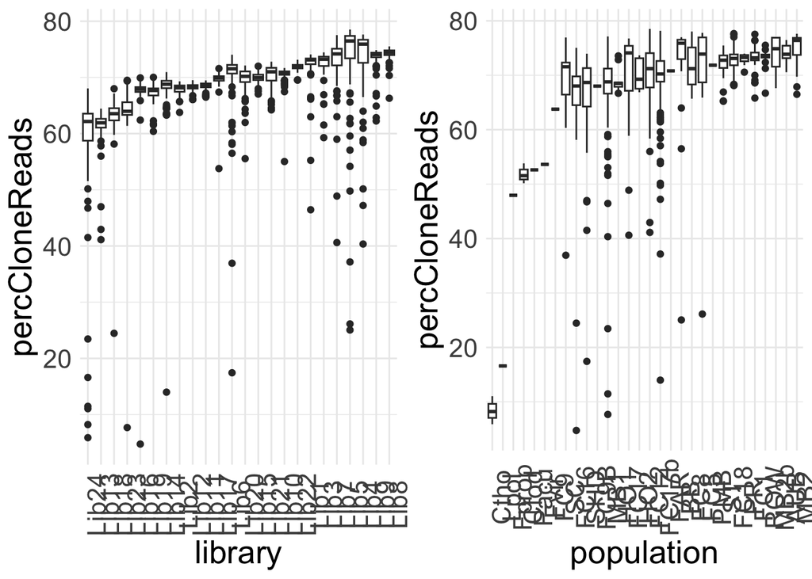

```r
cl <- read.delim("~/Documents/crayfish_lab/RSCseq2022/cloneFilterRes.txt", header = F) #N=2284

cl2 <- cl %>% separate(V1, into = c("ind", "inputPairs", "outputPairs", "discardedPairs", "clone1", "clone2"), sep = " ") %>% unite("percCloneReads", clone1:clone2, sep = ".")

cols2chg <- c("inputPairs", "outputPairs", "discardedPairs", "percCloneReads")
cl2[cols2chg] <- sapply(cl2[cols2chg],as.numeric)
cl2$ind <- gsub("FC815-212", "FC8-15-212", cl2$ind)
cl2$ind <- gsub("FC17B", "FC17b", cl2$ind)

# make pop columns
cl3 <- cl2 %>% mutate(SequenceID = ind) %>% mutate(pop = ind) %>% separate(pop, into = c("pop", "extra"), sep = "-") %>% select(-extra)
# Fix name discrepancies
cl3$SequenceID <- gsub("FC17B", "FC17b", cl3$SequenceID)
cl3$SequenceID <- gsub("SHD-M24", "SHD-M14", cl3$SequenceID)
cl3$SequenceID <- gsub("FC9B", "FC9b", cl3$SequenceID)

meta.df2 <- full_join(meta.df, cl3, by="SequenceID")


percClone.p <- ggplot(meta.df2 %>% filter(!pop == "empty"), aes(x=reorder(library, percCloneReads), y=percCloneReads)) +
  geom_boxplot(show.legend = F) +
  xlab("library") +
  theme_minimal() +
  theme(axis.text.x = element_text(angle = 90), text = element_text(size = 20))

percClone.p2 <- ggplot(meta.df2 %>% filter(!pop == "empty"), aes(x=reorder(pop, percCloneReads), y=percCloneReads)) +
  geom_boxplot(show.legend = F) +
  xlab("population") +
  theme_minimal() +
  theme(axis.text.x = element_text(angle = 90), text = element_text(size = 20))

# Get qual amounts
cl.tabA <- meta.df2 %>% filter(!pop == "empty") %>% summarise(mean=mean(percCloneReads), sd=sd(percCloneReads)) # 69%
cl.tabA <- cl.tabA %>% mutate(pop="all") %>% dplyr::select(pop, mean, sd)
cl.tabB <- meta.df2 %>% filter(!pop == "empty") %>% group_by(pop) %>% summarise(mean=mean(percCloneReads), sd=sd(percCloneReads))
cl.tab <- rbind(cl.tabA, cl.tabB)


# look for samples with high number of clones
cl.qts <- quantile(meta.df2$percCloneReads,probs=c(.05,.95), na.rm = T)
cl.qts.p <- ggplot(meta.df2 %>% filter(!pop == "empty"), aes(x=percCloneReads)) +
 # geom_density() +
  geom_histogram() +
  geom_vline(xintercept = cl.qts[1], color="red", linetype="dashed") +
  geom_vline(xintercept = cl.qts[2], color="red", linetype="dashed") +
  theme_minimal() +
  theme(text = element_text(size = 20))

high.clone <- meta.df2 %>% filter(percCloneReads > cl.qts[2])

hc.tab <- high.clone %>% group_by(pop) %>% tally()


ggarrange(percClone.p, percClone.p2)
```

## Trim and filter

(/mnt/home/adamsn23/RedSwampCrayfish/seq2022/scripts/6_trimQualityFilter_NEA.sh) Since the number of samples exceeds how many jobs that can be run on the HPCC I split them up: grep “FC”, grep “MB”, grep “SHD”; then did grep -v “FC” | grep -v “MB” | grep -v “SHD” to get the rest

```bash
#==================================================================================================
#   File: 6_trimQualityFilter.sh
#   Date: 01/07/20, 02/10/2022 (NEA), 06/29/2022 (NEA)
#   Description: Use Trimmomatic to trim reads and quality filter
#--------------------------------------------------------------------------------------------------
#   Authors: Jared Homola, Nicole Adams
#==================================================================================================

RUN_PATH=/mnt/home/adamsn23/RedSwampCrayfish/seq2022
SCR=/mnt/gs18/scratch/users/adamsn23/RSC/seq2022

### Need to rename files by removing the extra .1 or .2 that was inserted
find $SCR/cloneFilter -type f -name '*.1.1.fq.gz' | while read FILE ; do
    newfile="$(echo ${FILE} | sed -e 's/\.1.fq.gz/.fq.gz/')" ;
    mv "${FILE}" "${newfile}" ;
done

find $SCR/cloneFilter -type f -name '*.2.2.fq.gz' | while read FILE ; do
    newfile="$(echo ${FILE} | sed -e 's/\.2.fq.gz/.fq.gz/')" ;
    mv "${FILE}" "${newfile}" ;
done


mkdir $SCR/trimmed
mkdir $RUN_PATH/SHELL/trimQualityFilter
mkdir $RUN_PATH/QSTAT/trimQualityFilter

cd $RUN_PATH/SHELL/trimQualityFilter

ls $SCR/cloneFilter | grep "fq" | grep -v ".2.fq.gz" | grep "FC" | sed 's/\.1\.fq\.gz//g' | while read -r LINE
do
echo '#!/bin/sh
#SBATCH --nodes=1-4
#SBATCH --ntasks=1
#SBATCH -t 3:00:00
#SBATCH --cpus-per-task=4
#SBATCH --mem-per-cpu=8G
#SBATCH -J '$LINE'.trimQualityFilter
#SBATCH -o '$RUN_PATH'/QSTAT/trimQualityFilter/trimQualityFilter.'$LINE'.o
#SBATCH --error '$RUN_PATH'/QSTAT/trimQualityFilter/trimQualityFilter.'$LINE'.err

module purge
module load Trimmomatic/0.39-Java-11 Java/1.8.0_162

cd '$SCR'/cloneFilter
java -jar $EBROOTTRIMMOMATIC/trimmomatic-0.39.jar PE -threads 4 -phred33 \
'$LINE'.1.fq.gz '$LINE'.2.fq.gz \
'$SCR'/trimmed/'$LINE'_paired.1.fq.gz '$SCR'/trimmed/'$LINE'_unpaired.1.fq.gz \ '$SCR'/trimmed/'$LINE'_paired.2.fq.gz '$SCR'/trimmed/'$LINE'_unpaired.2.fq.gz \
ILLUMINACLIP:/mnt/research/Scribner_Lab/projects/RedSwampCrayfish_MISGP/SHELL/dependencies/adapters.fa:2:30:10 SLIDINGWINDOW:4:15 MINLEN:50

scontrol show job ${SLURM_JOB_ID}' > ./trimQualityFilter."$LINE".sh

sbatch ./trimQualityFilter."$LINE".sh

done


###### How many reads were trimmed and filtered? ######
#grep 'Surviving' $RUN_PATH/QSTAT/trimQualityFilter/trimQualityFilter*.o >> $RUN_PATH/OUT/trimQualityFilterRes.txt

#for FILE in QSTAT/trimQualityFilter/trimQualityFilter*.err
#do
#ind=$(echo $FILE | awk -F "/" '{print $3}' | awk -F "." '{print $2}')
#res=$(grep 'Surviving'  $FILE | awk -F " " '{print $4 "\t" $7 "\t" $8 "\t" $12 "\t" $13 "\t" $17 "\t" $18 "\t" $20 "\t" $21}')
#echo $ind $res >> OUT/trimQualityFilterRes.txt
#done
```

### Look at trim and filter results

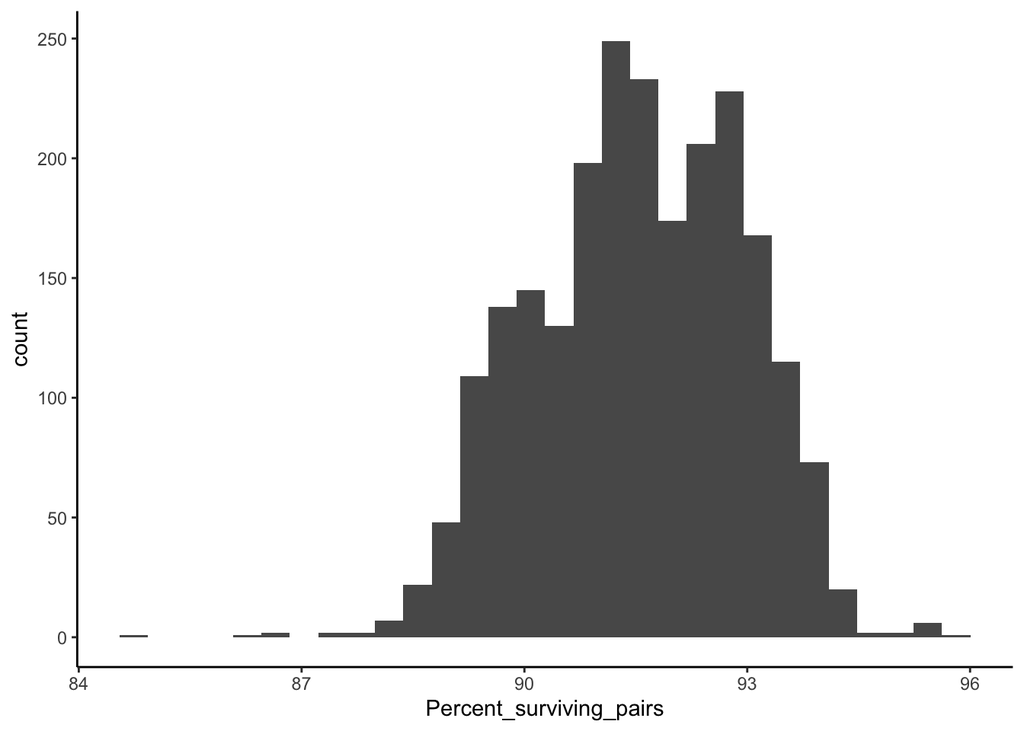

```r
fil <- read.delim("~/Documents/crayfish_lab/RSCseq2022/trimQualityFilterRes.txt", header = F) #N=2978

fil2 <- fil %>% separate(V1, into = c("ind", "inputPairs", "survivingPairs", "percSurvivingPairs", "survivingForward", "percSurvivingForward", "survivingReverse", "percSurvivingReverse", "dropped", "percDropped"), sep = " ")

perc2num <- c("percSurvivingPairs", "percSurvivingForward", "percSurvivingReverse", "percDropped")
fil2[perc2num] <- lapply(fil2[perc2num], gsub, pattern = "\\(", replacement = "")
fil2[perc2num] <- lapply(fil2[perc2num], gsub, pattern = "%)", replacement = "")

cols2chg2 <- c("inputPairs", "survivingPairs", "percSurvivingPairs", "survivingForward", "percSurvivingForward", "survivingReverse", "percSurvivingReverse", "dropped", "percDropped")
fil2[cols2chg2] <- sapply(fil2[cols2chg2],as.numeric)

fil3 <- fil2 %>% mutate(pop = ind) %>% separate(pop, into = c("pop", "extra"), sep = "-") %>% select(-extra)
fil4 <- fil3 %>% filter(!grepl("paired",ind))
# Fix name discrepancies
fil4$ind <- gsub("FC815-212", "FC8-15-212", fil4$ind)
fil4$ind <- gsub("FC17B", "FC17b", fil4$ind)
fil4$ind <- gsub("FC17B", "FC17b", fil4$ind)
fil4$ind <- gsub("SHD-M24", "SHD-M14", fil4$ind)
fil4$ind <- gsub("FC9B", "FC9b", fil4$ind)
fil4 <- fil4 %>% mutate(SequenceID=ind)

fil.tab <- fil4 %>% filter(ind=="empty") %>% summarise(mean=mean(percSurvivingPairs), sd=sd(percSurvivingPairs))

meta.df3 <- full_join(meta.df2, fil4, by="SequenceID")

trim.p <- ggplot(meta.df3, aes(x=percSurvivingPairs )) +
  geom_histogram() +
  xlab("Percent_surviving_pairs") +
  theme_classic()

trim.p
```

## Mapping to reference genome

### Make files needed for mapping

```bash
mkdir $SCRATCH/RSC/seq2022/trimmed/paired

mv $SCRATCH/RSC/seq2022/trimmed/*_paired* $SCRATCH/RSC/seq2022/trimmed/paired
```

### Map

(/mnt/home/adamsn23/RedSwampCrayfish/seq2022/scripts/8_bwaMemMap_NEA.sh)

```bash
#==================================================================================================
#   File: bwaMemMap.sh
#   Date: 01/07/21, 02/11/2022 (NEA), 07/04/2022 (NEA)
#   Description: Map reads to reference genome using bwa-mem
#--------------------------------------------------------------------------------------------------
#   Authors: Jared Homola, Nicole Adams
#==================================================================================================

#Define alias for project root directory
RUN_PATH=/mnt/home/adamsn23/RedSwampCrayfish/seq2022
SCR=/mnt/gs18/scratch/users/adamsn23/RSC/seq2022

mkdir $SCR/mapped
mkdir $RUN_PATH/SHELL/mapping
mkdir $RUN_PATH/QSTAT/mapping

cd $RUN_PATH/SHELL/mapping
ls $SCR/trimmed/paired | grep "fq" | grep -v ".2.fq.gz" | sed 's/\_paired.1\.fq\.gz//g' | grep "FC" | uniq | while read -r LINE
do

echo '#!/bin/sh
#SBATCH --nodes=1
#SBATCH --ntasks=1
#SBATCH -t 3:00:00
#SBATCH --cpus-per-task=1
#SBATCH --mem-per-cpu=36G
#SBATCH -J '$LINE'.bwaMemMap
#SBATCH -o '$RUN_PATH'/QSTAT/mapping/'$LINE'.bwaMemMap.o
#SBATCH --error '$RUN_PATH'/QSTAT/mapping/'$LINE'.bwaMemMap.err

module purge
module load GCC/6.4.0-2.28 OpenMPI/2.1.1 BWA/0.7.17 SAMtools/1.9

cd '$SCR'/trimmed/paired

bwa mem -R "@RG\tID:'$LINE'\tSM:'$LINE'\tPL:ILLUMINA\tLB:LB1" /mnt/home/adamsn23/RedSwampCrayfish/reference/GCF_020424385.1_ASM2042438v2_genomic.fna ./'$LINE'_paired.1.fq.gz ./'$LINE'_paired.2.fq.gz | samtools view -Sb - > ../../mapped/'$LINE'.pe.bam

scontrol show job ${SLURM_JOB_ID}' > ./bwaMemMap."$LINE".sh

sbatch ./bwaMemMap."$LINE".sh

done
```

### Sort mapped BAMs

(/mnt/home/adamsn23/RedSwampCrayfish/seq2022/scripts/10_sortBAM_NEA.sh)

```bash
#==================================================================================================
#   File: 10_sortBAM.sh
#   Date: 01/07/20, 02/15/2022 (NEA), 07/04/2022 (NEA)
#   Description: Sort BAM files
#--------------------------------------------------------------------------------------------------
#   Authors: Jared Homola, Nicole Adams
#==================================================================================================

#Define alias for project root directory
RUN_PATH=/mnt/home/adamsn23/RedSwampCrayfish/seq2022
SCR=/mnt/gs18/scratch/users/adamsn23/RSC/seq2022

mkdir $RUN_PATH/QSTAT/sortBAM
mkdir $RUN_PATH/SHELL/sortBAM_jobs
mkdir $RUN_PATH/OUT/sorted

cd $RUN_PATH/SHELL/sortBAM_jobs
ls $SCR/mapped | grep bam | awk -F "." '{print $1}' | grep "SHD" | sort | uniq | while read -r LINE
do
echo '#!/bin/sh
#SBATCH --nodes=1
#SBATCH --ntasks=1
#SBATCH -t 1:00:00
#SBATCH --cpus-per-task=1
#SBATCH --mem-per-cpu=8G
#SBATCH -J '$LINE'.sortBAM
#SBATCH -o '$RUN_PATH'/QSTAT/sortBAM/'$LINE'.sortBAM.o
#SBATCH --error '$RUN_PATH'/QSTAT/sortBAM/'$LINE'.sortBAM.err

module purge
module load GCC/9.3.0 SAMtools/1.15

samtools sort '$SCR'/mapped/'$LINE'.pe.bam -o '$RUN_PATH'/OUT/sorted/'$LINE'.pe.sorted.bam

scontrol show job ${SLURM_JOB_ID}' > ./sortBAM."$LINE".sh

sbatch ./sortBAM."$LINE".sh

done
```

## Filter mapped BAMs

(/mnt/home/adamsn23/RedSwampCrayfish/seq2022/scripts/11_filterBAMS_NEA.sh) -q 20=keep quality >= 20; -h=keep header; -f2=keep proper pairs(PROPER_PAIR)? ; -F2308=exclude unmapped reads, not primary alignment, supplementary alignment. see [this calculater](https://broadinstitute.github.io/picard/explain-flags.html)

```bash
#==================================================================================================
#   File: filterBAM.sh
#   Date: 01/07/21, 03/03/2022 (NEA), 07/05/2022 (NEA)
#   Description: Filter BAM files
#--------------------------------------------------------------------------------------------------
#   Authors: Jared Homola, Nicole Adams
#==================================================================================================

#Define alias for project root directory
RUN_PATH=/mnt/home/adamsn23/RedSwampCrayfish/seq2022
SCR=/mnt/gs18/scratch/users/adamsn23/RSC/seq2022

mkdir $RUN_PATH/QSTAT/filterBAM
mkdir $RUN_PATH/SHELL/filterBAM_jobs
mkdir $RUN_PATH/OUT/filtered

cd $RUN_PATH/SHELL/filterBAM_jobs
ls $RUN_PATH/OUT/sorted | grep bam | awk -F "." '{print $1}' | grep "SHD" | sort | uniq | while read -r LINE
do

echo '#!/bin/sh
#SBATCH --nodes=1
#SBATCH --ntasks=1
#SBATCH -t 1:00:00
#SBATCH --cpus-per-task=1
#SBATCH --mem-per-cpu=8G
#SBATCH -J '$LINE'.filterBAM
#SBATCH -o '$RUN_PATH'/QSTAT/filterBAM/'$LINE'.filterBAM.o
#SBATCH --error '$RUN_PATH'/QSTAT/filterBAM/'$LINE'.filterBAM.err

module purge
module load GCC/9.3.0 SAMtools/1.15

cd '$RUN_PATH'/OUT/sorted
samtools view -q 20 -h -f2 -F2308  '$LINE'.pe.sorted.bam | samtools view -Sb > ../filtered/'$LINE'.pe.sorted.filtered.bam

scontrol show job ${SLURM_JOB_ID}' > ./filterBAM."$LINE".sh

sbatch ./filterBAM."$LINE".sh

done
```

## Mapping metrics

(/mnt/home/adamsn23/RedSwampCrayfish/seq2022/scripts/11B_mapMetrics_NEA.sh)

```bash
#!/bin/sh
#SBATCH --nodes=1-4
#SBATCH --ntasks=6
#SBATCH -t 3:00:00
#SBATCH --cpus-per-task=4
#SBATCH --mem-per-cpu=8G
#SBATCH -J mapMetrics
#SBATCH -o /mnt/home/adamsn23/RedSwampCrayfish/seq2022/QSTAT/mapMetrics.o
#SBATCH --error /mnt/home/adamsn23/RedSwampCrayfish/seq2022/QSTAT/mapMetrics.err

#==================================================================================================
#   File: 11B_mapMetrics_NEA.sh
#   Date: 03/22/2022, 07/05/2022
#   Description: Get summary of mapping
#--------------------------------------------------------------------------------------------------
#       Authors: Nicole Adams
#==================================================================================================

module purge
module load GCC/9.3.0 SAMtools/1.15

#Define alias for project root directory
RUN_PATH=/mnt/home/adamsn23/RedSwampCrayfish/seq2022
SCR=/mnt/gs18/scratch/users/adamsn23/RSC/seq2022
BAM_PATH=/mnt/home/adamsn23/RedSwampCrayfish/seq2022/OUT/sorted


cd $RUN_PATH/SHELL

touch $BAM_PATH/mapSummary_seq2022.txt

for sample in `ls $BAM_PATH/*sorted.bam | cut -f1 -d'.'`
do
  samtools flagstat "$sample".pe.sorted.bam -@ 6  > "$sample"_mapSum.txt
 awk 'FNR == 1{ print FILENAME }' "$sample"_mapSum.txt >> $BAM_PATH/mapSummary_seq2022.txt
 cat "$sample"_mapSum.txt >> $BAM_PATH/mapSummary_seq2022.txt

done

for sample in $BAM_PATH/*mapSum.txt; do awk 'FNR == 1{ print FILENAME } {printf "%-20s %-40s\n", $1, $3}' OFS="\t" $sample | awk '
{
    for (i=1; i<=NF; i++)  {
        a[NR,i] = $i
    }
}
NF>p { p = NF }
END {
    for(j=1; j<=p; j++) {
        str=a[1,j]
        for(i=2; i<=NR; i++){
            str=str" "a[i,j];
        }
        print str
    }
}' >> $BAM_PATH/mapSummary_seq2022.2.txt; done

grep 'mnt' $BAM_PATH/mapSummary_seq2022.2.txt > $BAM_PATH/mapSummary_seq2022.3.txt

rm $BAM_PATH/*_mapSum.txt
```

### Repeat for filtered BAMs (11B_mapMetrics_filtered_NEA.sh)

```bash
#!/bin/sh
#SBATCH --nodes=1-4
#SBATCH --ntasks=8
#SBATCH -t 3:00:00
#SBATCH --cpus-per-task=6
#SBATCH --mem-per-cpu=8G
#SBATCH -J mapMetrics
#SBATCH -o /mnt/home/adamsn23/RedSwampCrayfish/seq2022/QSTAT/mapMetrics.o
#SBATCH --error /mnt/home/adamsn23/RedSwampCrayfish/seq2022/QSTAT/mapMetrics.err

#==================================================================================================
#   File: 11B_mapMetrics_NEA.sh
#   Date: 03/22/2022, 07/05/2022
#   Description: Get summary of mapping
#--------------------------------------------------------------------------------------------------
#       Authors: Nicole Adams
#==================================================================================================

module purge
module load GCC/9.3.0 SAMtools/1.15

#Define alias for project root directory
RUN_PATH=/mnt/home/adamsn23/RedSwampCrayfish/seq2022
SCR=/mnt/gs18/scratch/users/adamsn23/RSC/seq2022
BAM_PATH=/mnt/home/adamsn23/RedSwampCrayfish/seq2022/OUT/filtered


cd $RUN_PATH/SHELL

touch $BAM_PATH/mapSummary_seq2022_filt.txt

for sample in `ls $BAM_PATH/*filtered.bam | cut -f1 -d'.'`
do
  samtools flagstat "$sample".pe.sorted.filtered.bam -@ 6  > "$sample"_mapSum.txt
 awk 'FNR == 1{ print FILENAME }' "$sample"_mapSum.txt >> $BAM_PATH/mapSummary_seq2022_filt.txt
 cat "$sample"_mapSum.txt >> $BAM_PATH/mapSummary_seq2022_filt.txt

done

for sample in $BAM_PATH/*mapSum.txt; do awk 'FNR == 1{ print FILENAME } {printf "%-20s %-40s\n", $1, $3}' OFS="\t" $sample | awk '
{
    for (i=1; i<=NF; i++)  {
        a[NR,i] = $i
  }
}
NF>p { p = NF }
END {
    for(j=1; j<=p; j++) {
        str=a[1,j]
        for(i=2; i<=NR; i++){
            str=str" "a[i,j];
        }
        print str
    }
}' >> $BAM_PATH/mapSummary_seq2022_filt.2.txt; done

grep 'mnt' $BAM_PATH/mapSummary_seq2022_filt.2.txt > $BAM_PATH/mapSummary_seq2022_filt.3.txt

rm $BAM_PATH/*_mapSum.txt
```

#### Examine mapping results in R

I ran summary stats for sorted bams (.pe.sorted.bam) and filtered bams (.pe.sorted.filtered.bam)

```r
msumA <- read.table("~/Documents/crayfish_lab/RSCseq2022/mapSummary_seq2022.3.txt")

colnames(msumA) <- c("Sample", "QCpassedReads", "primary", "secondary", "supplementary", "duplicates", "primaryDuplicates", "mapped", "primaryMapped", "paired", "read1", "read2", "properlyPaired", "itselfYmateMapped", "singletons", "mateMappedDiffChr", "mateMappedDiffChr_mapQ5")

nothanks <- c("a", "b", "c", "d", "e", "f", "g", "h")
msum <- msumA %>% separate(Sample, c("a", "b", "c", "d", "e", "f", "g", "h", "i"), sep = "/") %>% select(-nothanks) %>%
  separate(i, c("Sample", "stuff"), sep = "_") %>% select(-stuff)

msum$percentMap <- (msum$mapped/msum$QCpassedReads)*100
msum$percentPaired <- (msum$properlyPaired/msum$paired)*100
msum$percentSingle <- (msum$singletons/msum$properlyPaired)*100

# Fix name discrepancies
msum$Sample <- gsub("FC815-212", "FC8-15-212", msum$Sample)
msum$Sample <- gsub("FC17B", "FC17b", msum$Sample)
msum$Sample <- gsub("FC17B", "FC17b", msum$Sample)
msum$Sample <- gsub("SHD-M24", "SHD-M14", msum$Sample)
msum$Sample <- gsub("FC9B", "FC9b", msum$Sample)

msum <- msum %>% mutate(SequenceID=Sample)

# add in pop names
msum <- msum %>% mutate(pop = Sample) %>% separate(pop, into = c("pop", "extra"), sep = "-") %>% select(-extra)


meta.df4 <- full_join(meta.df3, msum, by="SequenceID")


msum.p <- ggplot(msum %>% filter(!Sample == "empty"), aes(x=reorder(pop, percentMap), y=percentMap)) +
  geom_boxplot(show.legend = F) +
 # geom_jitter(aes(alpha=0.4), size=0.8, show.legend = F) +
  xlab("population") +
  theme_minimal() + theme(axis.text.x = element_text(angle = 90), text = element_text(size = 20))

msum.p2 <- ggplot(meta.df4 %>% filter(!Sample == "empty") , aes(x=reorder(library, percentMap), y=percentMap)) +
  geom_boxplot(show.legend = F) +
 # geom_jitter(aes(alpha=0.4), size=0.8, show.legend = F) +
  xlab("library") +
  theme_minimal() + theme(axis.text.x = element_text(angle = 90), text = element_text(size = 20))


msum.p.clark <- msum %>% filter(!pop %in% c("Cfod", "Ctho", "Fprop", "Fvir", "Lpol", "Pacu")) %>% filter(!Sample == "empty")
msum.pc.tab <- msum.p.clark %>% group_by(pop) %>% summarise(meanPercentMap=mean(percentMap, na.rm=TRUE), meanPercentPaired=mean(percentPaired, na.rm=TRUE))
msum.pc.tab2 <- msum.p.clark %>% summarise(meanPercentMap=mean(percentMap, na.rm=TRUE), meanPercentPaired=mean(percentPaired, na.rm=TRUE))
msum.pc.tab2$Samples <- "P.clarkii"

msum.oth.sp <- msum %>% filter(pop %in% c("Cfod", "Ctho", "Fprop", "Fvir", "Lpol", "Pacu"))
msum.sp.tab <- msum.oth.sp %>% group_by(pop) %>% summarise(meanPercentMap=mean(percentMap, na.rm=TRUE), meanPercentPaired=mean(percentPaired, na.rm=TRUE))
msum.sp.tab2 <- msum.oth.sp %>% summarise(meanPercentMap=mean(percentMap, na.rm=TRUE), meanPercentPaired=mean(percentPaired, na.rm=TRUE))
msum.sp.tab2$Samples <- "OtherSpecies"

msum.tab.all <- rbind(msum.pc.tab, msum.sp.tab)
msum.tab.all2 <- rbind(msum.pc.tab2, msum.sp.tab2)

kable(msum.tab.all2, digits = 2, caption = "Mapping summary") %>% kableExtra::kable_styling()
```

Mapping summary

| meanPercentMap | meanPercentPaired | Samples |
| --- | --- | --- |
| 95.43 | 89.35 | P.clarkii |
| 94.01 | 71.38 | OtherSpecies |

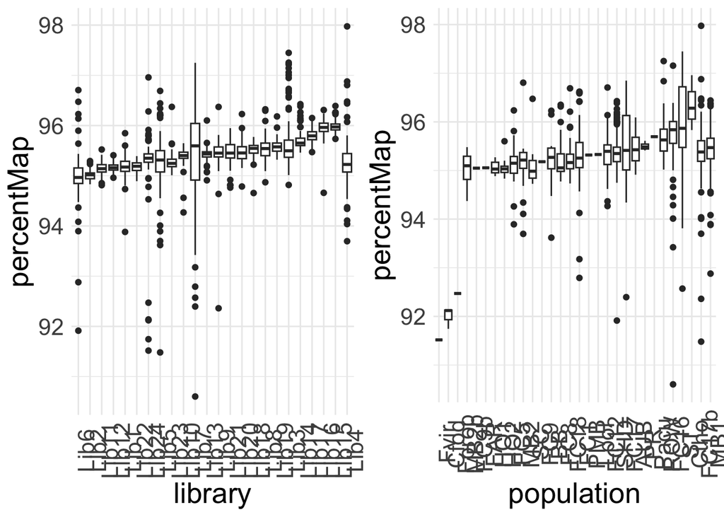

```r
ggarrange(msum.p2, msum.p)
```

### Read counts

(/mnt/home/adamsn23/RedSwampCrayfish/seq2022/scripts/12_countReads_NEA.sh)

```bash
#!/bin/sh
#SBATCH --nodes=1-4
#SBATCH --ntasks=8
#SBATCH -t 1:00:00
#SBATCH --cpus-per-task=4
#SBATCH --mem-per-cpu=8G
#SBATCH -J Count_reads
#SBATCH -o /mnt/home/adamsn23/RedSwampCrayfish/seq2022/QSTAT/Count_reads.o
#SBATCH --error /mnt/home/adamsn23/RedSwampCrayfish/seq2022/QSTAT/Count_reads.err

#==================================================================================================
#   File: Count_reads.sh
#   Date: 04/22/19, 03/11/2022 (NEA), 07/05/2022 (NEA)
#   Description: Flip the orientation of the Best RAD reads
#       Run: Interactively - array
#--------------------------------------------------------------------------------------------------
#       Authors: Jared Homola, Seth Smith, Nicole Adams
#==================================================================================================

#Define alias for project root directory
RUN_PATH=/mnt/home/adamsn23/RedSwampCrayfish/seq2022
SCR=/mnt/gs18/scratch/users/adamsn23/RSC/seq2022

cd $RUN_PATH/SHELL

touch $RUN_PATH/OUT/Read_counts.txt

# old way
#ls $SCR/RSC/trimmed/paired | grep "fq" | grep -v ".2.fq.gz" | grep -v "rem" | awk -F "." '{print $1}' | sort | uniq | while read -r LINE
#do
#   echo $LINE >> $RUN_PATH/OUT/Read_counts.txt
#   zcat $SCR/RSC/trimmed/paired/$LINE.1.fq.gz | echo $((`wc -l`/4)) >> #$RUN_PATH/OUT/Read_counts.txt
#done

# new way, puts name and number on same line
ls $SCR/trimmed/paired | grep "fq" | grep -v ".2.fq.gz" | grep -v "rem" | awk -F "." '{print $1}' | sort | uniq | while read -r LINE
do
ind=$(echo $LINE)
dat=$(zcat $SCR/trimmed/paired/$LINE.1.fq.gz | echo $((`wc -l`/4)))
echo $ind $dat >> $RUN_PATH/OUT/Read_counts.txt
done
```

### Examine read counts in R

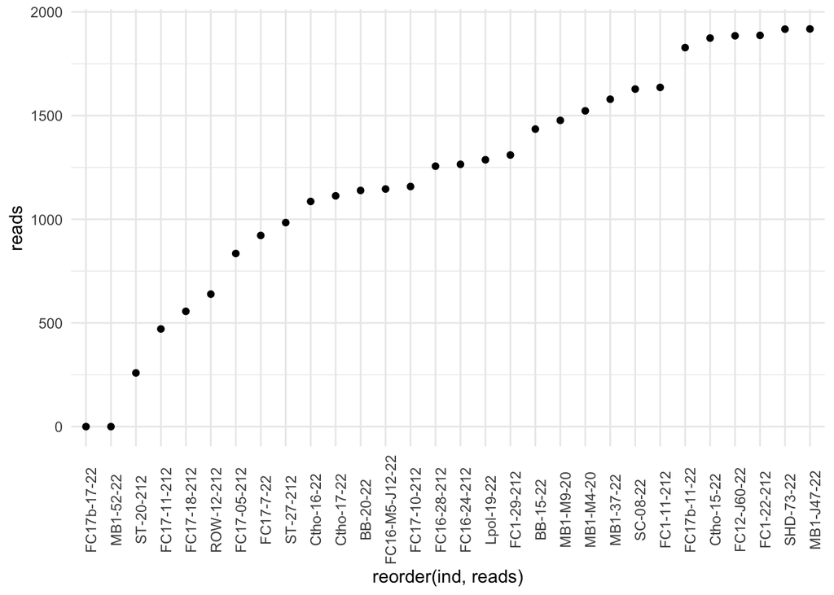

```r
counts.a <- as.data.frame(read.delim("~/Documents/crayfish_lab/RSCseq2022/Read_counts.txt", header = FALSE))

counts.b <- counts.a %>% separate(V1, into = c("ind", "reads"), sep = " ") %>%
  separate(ind, into = c("ind", "stuff"), sep = "_") %>% select(-stuff)

# some samples are present twice in the file... so remove them
counts.c <- counts.b %>% distinct(ind, .keep_all = T)

# Fix name discrepancies
counts.c$ind <- gsub("FC815-212", "FC8-15-212", counts.c$ind)
counts.c$ind <- gsub("FC17B", "FC17b", counts.c$ind)
counts.c$ind <- gsub("FC17B", "FC17b", counts.c$ind)
counts.c$ind <- gsub("SHD-M24", "SHD-M14", counts.c$ind)
counts.c$ind <- gsub("FC9B", "FC9b", counts.c$ind)

counts.c <- counts.c %>% mutate(SequenceID=ind)


# add in pop names
counts.c <- counts.c %>% mutate(pop = ind) %>% separate(pop, into = c("pop", "extra"), sep = "-") %>% select(-extra)

counts <- counts.c %>% mutate(reads= as.numeric(reads))


meta.df5 <- full_join(meta.df4, counts, by="SequenceID")



counts.p <- ggplot(counts %>% filter(!pop == "empty"), aes(x=reorder(pop, reads), y=reads)) +
  geom_boxplot(show.legend = F) +
 # geom_jitter(aes(alpha=0.4), size=0.8, show.legend = F) +
  xlab("populations") +
  theme_minimal() + theme(axis.text.x = element_text(angle = 90), text = element_text(size = 20))



# identify low read samples:
qts <- quantile(counts$reads,probs=c(.05,.95))
counts.p2 <- ggplot(counts %>% filter(!pop == "empty"), aes(x=reads)) +
 # geom_density() +
  geom_histogram() +
  geom_vline(xintercept = qts[1], color="red", linetype="dashed") +
  geom_vline(xintercept = qts[2], color="red", linetype="dashed") +
  theme_minimal() +
  theme(text = element_text(size = 20))

low.counts <- counts %>% filter(reads < qts[1]) %>% arrange(reads)

low.cnt.p <- ggplot(low.counts %>% filter(reads <2000), aes(x=reorder(ind, reads), y=reads)) +
  geom_point() +
  theme_minimal() +
  theme(axis.text.x = element_text(angle = 90))

low.cnt.p
```

## Estimate depth of coverage with bedtools

```bash
#==================================================================================================
#   File: 12B_coverage_NEA.sh
#   Date: 07/06/2022 (NEA)
#   Description: Get coverage
#--------------------------------------------------------------------------------------------------
#   Authors: Nicole Adams
#==================================================================================================

# Define alias for project root directory
RUN_PATH=/mnt/home/adamsn23/RedSwampCrayfish/seq2022
SCR=/mnt/gs18/scratch/users/adamsn23/RSC/seq2022

mkdir $RUN_PATH/OUT/filtered/coverage
touch $RUN_PATH/OUT/filtered/coverage/covSummary.genomecov.txt
touch $RUN_PATH/OUT/filtered/coverage/covSummary.genomecov.rm0.txt


cd $RUN_PATH/SHELL/coverage
ls $RUN_PATH/OUT/filtered | grep "bam"| awk -F "." '{print $1}' | grep -v "FC5" | grep "FC" | uniq | while read -r LINE
do

echo '#!/bin/sh
#SBATCH --nodes=1
#SBATCH --ntasks=1
#SBATCH -t 3:00:00
#SBATCH --cpus-per-task=1
#SBATCH --mem-per-cpu=36G
#SBATCH -J '$LINE'.coverage
#SBATCH -o '$RUN_PATH'/QSTAT/filterBAM/'$LINE'.coverage.o
#SBATCH --error '$RUN_PATH'/QSTAT/filterBAM/'$LINE'.coverage.err

module purge
module load GCC/8.3.0 OpenMPI/3.1.4 pybedtools/0.8.1 SAMtools/1.15

cd $RUN_PATH/OUT/filtered

 bedtools genomecov -dz -ibam '$RUN_PATH'/OUT/filtered/'$LINE'.pe.sorted.filtered.bam  > '$RUN_PATH'/OUT/filtered/coverage/'$LINE'_cov.genomecov.txt

scontrol show job ${SLURM_JOB_ID}' > ./coverage."$LINE".sh

sbatch ./coverage."$LINE".sh

done
```

#### Combine coverage output

```bash
awk '{if($3<500) {total+=$3; ++lines}} END {print FILENAME," ",total/lines}' filtered/coverage/*_cov.genomecov.txt >> filtered/coverage/covSummary.genomecov2022.txt
#cat coverage/"$sample"_cov.genomecov.txt|awk '$3!=0{print$0}'|awk '{if($3<500) {total+=$3; ++lines}} END {print FILENAME," ",total/lines}' coverage/"$sample"_cov.genomecov.txt >> cov/covSummary.genomecov.rm0.txt

#rm coverage/"$sample"_cov.genomecov.txt
```